# Модели случайного блуждания

Математическое моделирование

Тойчубекова Асель Нурлановна

kulyabov-ds@rudn.ru

Российский университет дружбы народов

2026-05-01

# Информация

## Докладчик

- Тойчубекова Асель Нурлановна
- Студент 3 курса
- факультет физико-математических и естественных наук
- Российский университет дружбы народов им. П. Лумумбы
- 1032235033@rudn.ru

# Введение

## Введение

Математическое моделирование случайных процессов — раздел прикладной математики, позволяющий описывать явления с неопределённой динамикой (движение частиц, финансовые рынки, распространение информации).

Одной из базовых моделей является случайное блуждание, при котором изменения состояния происходят случайным образом.

Эта модель широко используется в физике, биологии, экономике и информатике для анализа и моделирования сложных систем.

## История случайных блужданий

- 1827 г. — Роберт Браун обнаружил хаотичное движение частиц в жидкости (броуновское движение).
- 1900 г. — Луи Башелье применил модель случайного блуждания к финансовым рынкам в работе «Теория спекуляции».
- 1905 г. — Альберт Эйнштейн объяснил броуновское движение с помощью молекулярно-кинетической теории.
- 1905 г. — Мариан Смолуховский независимо разработал аналогичную теорию.
- 1905 г. — Карл Пирсон ввёл термин «random walk» и предложил пример с «пьяным человеком».

# Модели случайного блуждания

## Случайный процесс

**Случайным процессом** называется семейство случайных величин

$$\{X(t), \; t \in T\},$$

где $T$ — множество значений параметра (обычно времени).

- Если $T$ счётно, говорят о процессе **с дискретным временем**.
- Если $T$ непрерывно, говорят о процессе **с непрерывным временем**.

Случайный процесс полностью характеризуется своими **конечномерными распределениями**.

## Одномерное дискретное случайное блуждание

**Одномерное дискретное случайное блуждание** — это случайный процесс

$$\{Y_n\}, \quad n \geq 0,$$

с дискретным временем, задаваемый формулой:

$$Y_n = Y_0 + \sum_{i=1}^{n} X_i$$

где:

- $Y_0$ — начальная позиция (обычно $Y_0 = 0$);
- $X_1, X_2, \ldots, X_n$ — независимые одинаково распределённые случайные величины («шаги»);

# Математические свойства

## Математическое ожидание и дисперсия

Пусть

$$E[X_i] = \mu, \quad \operatorname{Var}(X_i) = \sigma^2$$

для всех $i$. Тогда для процесса $Y_n$ (при $Y_0 = 0$):

$$E[Y_n] = n \cdot \mu$$

$$\operatorname{Var}(Y_n) = n \cdot \sigma^2$$

Для симметричного простого блуждания:

$$\mu = 0, \quad \sigma^2 = 1$$

поэтому:

$$E[Y_n] = 0, \quad \operatorname{Var}(Y_n) = n$$

## Центральная предельная теорема

По центральной предельной теореме, при большом числе шагов $n$ нормированное блуждание сходится по распределению к стандартному нормальному закону:

$$\frac{Y_n}{\sqrt{n}} \xrightarrow{d} \mathcal{N}(0, 1), \quad n \to \infty$$

Это фундаментальный результат, связывающий дискретные модели с непрерывными.

Стандартное отклонение растёт как $\sqrt{n}$ — это характерный признак диффузионного поведения.

## Теорема Пойа о возвратности

Теорема Пойа (1921) определяет возвратность в зависимости от размерности:

| Размерность $d$ | Вероятность возврата | Тип |
| --- | --- | --- |
| $d = 1$ | 1 | Возвратное |
| $d = 2$ | 1 | Возвратное |
| $d = 3$ | ≈ 0.3405 | Невозвратное |
| $d \ge 4$ | < 0.3405 | Невозвратное |

## Принцип отражения

Пусть $T$ — момент первого достижения уровня $r$. Тогда вероятность того, что максимум блуждания за $n$ шагов превысит $r$, связана с вероятностью нахождения в точке $r$ в момент $n$.

Обозначим:

$$M_n = \max \{Y_0, Y_1, \ldots, Y_n\}$$

Тогда для симметричного блуждания:

$$P(M_n \geq k) = 2 \cdot P(Y_n \geq k) - P(Y_n = k)$$

# Классификация случайных блужданий

## Дискретные случайные блуждания

| Модель | Ключевые свойства | Характеристики | Применение |
| --- | --- | --- | --- |
| Симметричное (простое) | $p = q = 1/2$, сдвиг $\pm 1$ | $\mathbb{E}[S_n]=0$, $\text{Var}(S_n)=n$; возвратное в 1D и 2D | Базовая теоретическая модель |
| Асимметричное (с дрейфом) | $p \neq q$, $\mu = p - q$ | $\mathbb{E}[S_n]=n\mu$; невозвратное при $p \neq 1/2$ | Задача о разорении: $P_k = \dfrac{1-(q/p)^k}{1-(q/p)^N}$ |
| Многомерное ($\mathbb{Z}^d$) | $2d$ равновероятных направлений | Возвратное при $d \leq 2$; невозвратное при $d \geq 3$ (теорема Пойа) | Модели диффузии в пространстве |

## Непрерывные случайные блуждания

| Модель | Ключевые свойства | Характеристики | Применение |
| --- | --- | --- | --- |
| Броуновское движение | Независимые, стационарные гауссовы приращения; $W(0)=0$ | $W(t)-W(s) \sim \mathcal{N}(0,\,t-s)$; предел дискретного блуждания (теорема Донскера) | Физика, стохастический анализ |
| Геометрическое броуновское движение | $dS_t = \mu S_t\,dt + \sigma S_t\,dW_t$ | $S_t = S_0\exp[(\mu-\sigma^2/2)t + \sigma W_t]$; всегда положительно | Формула Блэка–Шоулза, цены активов |
| Дробное броуновское движение (fBm) | Параметр Хёрста $H\in(0,1)$ | $\text{Var} \sim t^{2H}$; при $H>1/2$ — супердиффузия, при $H<1/2$ — субдиффузия | Финансы с долгой памятью, турбулентность |

## Обобщённые модели случайных блужданий

| Модель | Ключевые свойства | Характеристики | Применение |
| --- | --- | --- | --- |
| Самоизбегающее блуждание (SAW) | Запрет повторного посещения узлов | $\langle R_n^2\rangle \sim n^{2\nu}$, $\nu \approx 0.588$ в 3D | Полимерные цепи в растворе |
| Блуждание Леви | Шаги с тяжёлыми хвостами: $P(\vert\xi\vert>x)\sim x^{-\alpha}$, $0<\alpha<2$ | Бесконечная дисперсия; $\langle x^2\rangle \sim t^{2/\alpha}$ (супердиффузия) | Турбулентность, поведение животных, финансы |
| CTRW | Случайное время ожидания: $\psi(t)\sim t^{-1-\beta}$ | $\langle x^2\rangle \sim t^\beta$, $0<\beta<1$ (субдиффузия) | Аморфные полупроводники, диффузия в клетках |
| Блуждание на графах | Переход $P(v\to u)=1/\deg(v)$; марковская цепь | Стац. распределение $\pi(v)=\deg(v)/2\vert E\vert$ | PageRank, кластеризация, соцсети |

# Практическое применение

## Финансовые рынки и стоимость ценных бумаг

- **Башелье (1900):** цены меняются случайно, как случайное блуждание.
- Это привело к модели геометрического броуновского движения (основа Блэка–Шоулса).
- **Фама (1970):** гипотеза эффективного рынка — цены отражают всю информацию, поэтому их изменения непредсказуемы.
- Следствие: прошлые данные не помогают предсказывать будущие цены.
- **Мэлкил (1973):** пассивное индексное инвестирование часто не уступает активному управлению.

## Физика: броуновское движение и диффузия

Броуновское движение — хаотическое движение частиц в жидкости или газе из-за тепловых столкновений. Эйнштейн (1905) показал закон диффузии:

$$\langle x^2 \rangle = 2Dt$$

Это аналог дискретного случайного блуждания:

$$\operatorname{Var}(Y_n) = n$$

Такие процессы описывают диффузию, теплоперенос и движение частиц в физике и биологии.

## Биология: эволюция и генетика

- **Генетический дрейф** — случайные изменения частот аллелей в популяции (моделируется случайным блужданием).
- **Молекулярная эволюция** — нейтральные мутации описываются диффузионными моделями (модель Кимуры).
- **Движение микроорганизмов** — бактерии (например, E. coli) движутся как случайное блуждание с чередованием прямых участков и поворотов.
- **Эпидемиология** — распространение инфекций на сетях моделируется стохастическими процессами.

## Информатика и алгоритмы

- **Рандомизированные алгоритмы** — например, алгоритм Пападимитриу для 2-SAT использует случайное блуждание.
- **PageRank** — ранжирование страниц в Google основано на случайном блуждании по графу ссылок.
- **Машинное обучение** — случайные блуждания используются в обучении с подкреплением и алгоритмах на графах.

# Моделирование и численные методы

## Алгоритм симуляции дискретного блуждания

Для численного моделирования одномерного случайного блуждания используется следующий алгоритм:

1. Задать начальное положение $Y_0 = 0$
2. Для каждого шага $i$ от 1 до $N$: сгенерировать $X_i$ из распределения Бернулли (+1 с вероятностью $p$, -1 с вероятностью $1-p$)
3. Вычислить $Y_i = Y_{i-1} + X_i$
4. Записать или визуализировать траекторию $\{Y_0, Y_1, \ldots, Y_N\}$

## Код на Julia для одного случайного блуждания и для нескольких траекторий

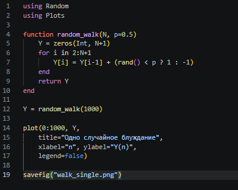

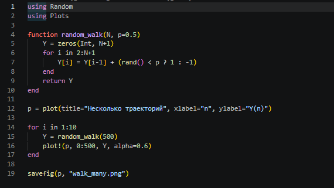

## Вывод програм

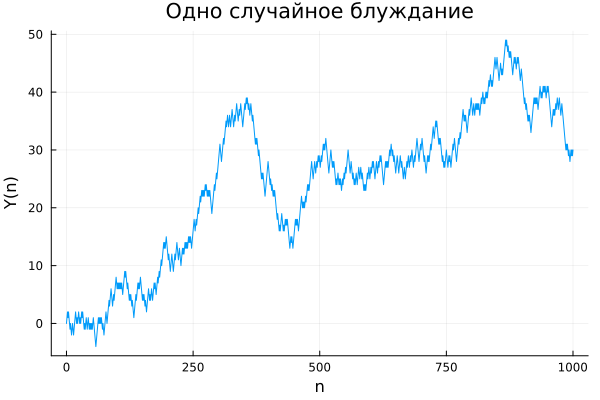

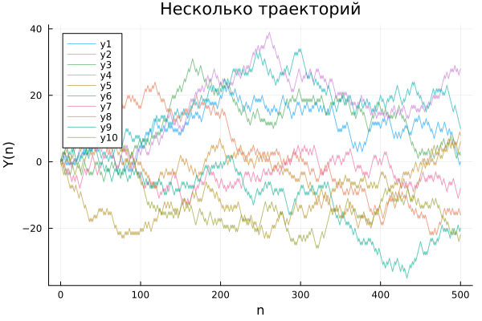

## Статистические свойства симулированных траекторий

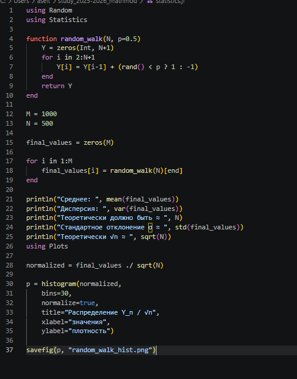

Код для вывода статистических свойств

## Вывод статистических свойств симулированных траекторий

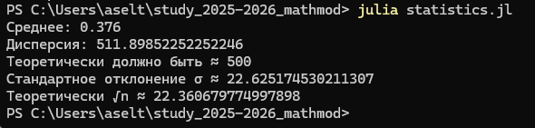

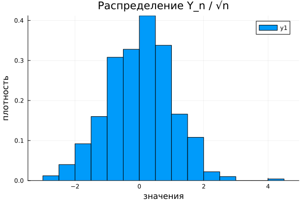

## Метод Монте-Карло для оценки вероятностей

Для сложных задач, не имеющих аналитического решения, используют метод Монте-Карло: проводят большое число ($M \gg 1$) независимых симуляций блуждания и оценивают искомые вероятности по частотам. Например, вероятность разорения оценивается как:

$$P(\text{разорение}) \approx \frac{\text{число симуляций, где } Y_n \leq 0}{M}$$

# Заключение

## Заключение

Случайное блуждание — универсальная модель стохастических процессов. При простой конструкции оно обладает фундаментальными свойствами: линейным ростом дисперсии, возвратностью в малых размерностях, сходимостью к нормальному распределению. Модель связывает строгую математическую теорию с широким кругом приложений в физике, финансах, биологии и информатике.

## Список литературы

1. Большая российская энциклопедия (2015, обновл. 2024). Статья «Случайное блуждание». — URL: https://bigenc.ru/c/sluchainoe-bluzhdanie-05f9a5
2. Элементы.ру — научно-популярное издание. Статья «Случайные блуждания» (Математические этюды). — URL: https://book.etudes.ru/articles/randomwalk/
3. Elementy.ru — Епифанов Е. Задача «Случайные блуждания». — URL: https://elementy.ru/problems/1033/Sluchaynye_bluzhdaniya
4. Колесников А.В. Курс лекций «Теория вероятностей». Лекция 3: Случайное блуждание. — НИУ ВШЭ, 2017. — URL: https://math.hse.ru/data/2017/03/19/1170010755/
5. Wikipedia (ru). Статья «Случайное блуждание». — URL: https://ru.wikipedia.org/wiki/Случайное_блуждание